# QTW_CS4_ARIMA

## ARIMA - Time series analysis on 'Microsoft' stock data(MSFT)

### Team: Hieu Nguyen, Nithya Devadoss, Ramesh Simhambhatla, Ramya Mandava

### Date: 10/21/2018

## Abstract

In time series analysis, an autoregressive integrated moving average (ARIMA) model is a generalization of an autoregressive moving average (ARMA) model. Both of these models are fitted to time series data either to better understand the data or to predict future points in the series (forecasting). Since stationarity is an assumption underlying many statistical procedures used in time series analysis, non-stationary data is often transformed to become stationary.A stationary time series is one whose statistical properties such as mean, variance, autocorrelation, etc. are all constant over time. In this case study, we will acquire stock data for Microsoft Corporation (Stock symbol: MSFT), transform the data to stationary and conduct tests to determine most appropriate ARIMA model.

## Introduction

We acquire Microsoft Corporation (MSFT) stock closing data . We have limited the data from January 2014 to September 2018. The Investors Exchange (IEX) provides this data through an API available in Python "pandas_datareader" package. Our objective is to investigate the time series data is stationary and test using a ARIMA model. We would test ARIMA using our intuition with ACF and PACF, and then a grid search (brute force) technique is used to determine the best p, q and d values that yield the least Root Mean Squared Error.

Stationary and Differencing:

https://otexts.org/fpp2/stationarity.html

ARIMA Model:

with-python/

ACF and PACF:

https://machinelearningmastery.com/gentle-introduction-autocorrelation-partial-autocorrelation/

ACF: We can calculate the correlation for time series observations with observations with previous time steps, called lags. Because the correlation of the time series observations is calculated with values of the same series at previous times, this is called a serial correlation, or an autocorrelation. The Pearson’s correlation coefficient is a number between -1 and 1 that describes a negative or positive correlation respectively. A value of zero indicates no correlation.

A partial autocorrelation is a summary of the relationship between an observation in a time series with observations at prior time steps with the relationships of intervening observations removed. It contrasts with the autocorrelation function, which does not control for other lags.

```python
import pandas as pd
from pandas import read_csv
from pandas import datetime
from matplotlib import pyplot as plt
import matplotlib
%matplotlib inline
```

Now we will subtract the trend from our data to make it (more) stationary

In reality this data shows some seasonality, and there are seasonal models available, but for the purposes of the exercise we will ignore seasonality.

Next we will try some differencing to try and eliminate seasonality and make the series further staionary. This determines if we use a difference term or not. In this example, 1 shift ($y_t - y_{t-1}$) is used, so d=1

Now we take a look at the Autocorrelation and Partial Autocorrelation plots

Now we fit a model of the proper order and look at the output

```python
import datetime
pd.core.common.is_list_like = pd.api.types.is_list_like
from pandas_datareader import data as web
start = datetime.datetime(2014, 1, 1)
end = datetime.datetime(2018, 9, 1)
price = web.DataReader('MSFT', 'iex', start, end)['close']
price.index = pd.to_datetime(price.index)
```

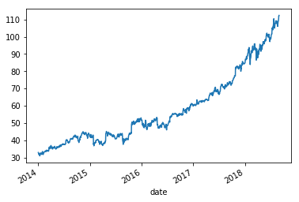

```python
price.plot()
```

## Analysis of plot

Reviewing the plot above, there seems to be a trend in the plot and time series with trends, or with seasonality, are not stationary — the trend and seasonality will affect the value of the time series at different times. On the other hand, a white noise series is stationary — it does not matter when you observe it, it should look much the same at any point in time.

Dicky-Fuller test is popular for checking the seasonality in a given time series data.Statsmodels library provides tools to implement Dicky-Fuller test and to plot other related tests.

The test_stationarity() function displays the results of Dickey-Fuller test along with the rolling mean and standard deviation.

```python
price.head()
```

```
date
2014-01-02    33.0940
2014-01-03    32.8713
2014-01-06    32.1767
2014-01-07    32.4261
2014-01-08    31.8472
Name: close, dtype: float64
```

```python
from statsmodels.tsa.stattools import adfuller
def test_stationarity(timeseries):

    #Determing rolling statistics
    rolmean = timeseries.rolling(12).mean()
    rolstd = timeseries.rolling(12).std()

    #Plot rolling statistics:
    orig = plt.plot(timeseries, color='blue',label='Original')
    mean = plt.plot(rolmean, color='red', label='Rolling Mean')
    std = plt.plot(rolstd, color='black', label = 'Rolling Std')
    plt.legend(loc='best')
    plt.title('Rolling Mean & Standard Deviation')
    plt.show(block=False)

    #Perform Dickey-Fuller test:
    print('Results of Dickey-Fuller Test:')
    dftest = adfuller(timeseries, autolag='AIC')
    dfoutput = pd.Series(dftest[0:4], index=['Test Statistic','p-value','#Lags Used','Number of Observations Used'])
    for key,value in dftest[4].items():
        dfoutput['Critical Value (%s)'%key] = value
    print(round(dfoutput, 3))
```

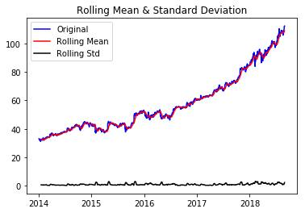

```
Results of Dickey-Fuller Test:
Test Statistic                    2.318
p-value                           0.999
#Lags Used                        9.000
Number of Observations Used    1166.000
Critical Value (1%)              -3.436
Critical Value (5%)              -2.864
Critical Value (10%)             -2.568
dtype: float64
```

```python
test_stationarity(price)
```

Statistical tests make strong assumptions about the data. They can only be used to inform the degree to which a null hypothesis can be rejected or fail to be reject. The result must be interpreted for a given problem to be meaningful.

The intuition behind Dickey-Fuller unit root test implemented above is that it determines how strongly a time series is defined by a trend.

Results provide a test statistic of 2.318 which is much higher than even the 10% critical value, hence it is evident that the time-series data is non-sationary.

## Differencing

One way of making data more stationary is by subtracting the trend from our data or in other words-compute the differences between consecutive observations. This is known as differencing.

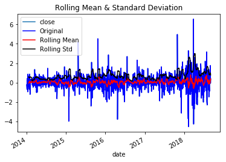

```
Results of Dickey-Fuller Test:
Test Statistic                  -13.195
p-value                           0.000
#Lags Used                        8.000
Number of Observations Used    1166.000
Critical Value (1%)              -3.436
Critical Value (5%)              -2.864
Critical Value (10%)             -2.568
dtype: float64
```

```python
diff=price-price.shift()
diff.dropna(inplace=True)
diff.plot()
test_stationarity(diff)
```

## Modeling using ARIMA

ARIMA is a class of model that captures a suite of different standard temporal structures in time series data.

ARIMA stands for: [1]

**AR**: Autoregression.

- Current prediction depends on the past results
- Similar to a Markov chain, but can be longer than 1 step

**I**: Integrated.

- Not only is the past result import, but the DIFFERENCES between the past results are important

**MA**: Moving Average.

- The average of previous results is also important.

Each of these components are explicitly specified in the model as a parameter. A standard notation is used of `ARIMA(p,d,q)` where the parameters are substituted with integer values to quickly indicate the specific ARIMA model being used.

The parameters of the ARIMA model are defined as follows:

- **p**: This term represents the lag order which is the number of lag observations included in the model.
- **d**: This is the degree of differencing indicating the number of times the raw observations are differenced.
- **q**: This is the order of moving average.

It is important to pick the right combinations of p,q and d. The below functions help choose the optimal values for p,q and d.

- **Autocorrelation Function (ACF)**: The plot summarizes the correlation of an observation with lag values. The x-axis shows the lag and the y-axis shows the correlation coefficient between -1 and 1 for negative and positive correlation.
- **Partial Autocorrelation Function (PACF)**: The plot summarizes the correlations for an observation with lag values that is not accounted for by prior lagged observations.

## Autocorrelation Function(ACF)

```
Text(0.5,1,'Autocorrelation Function')
```

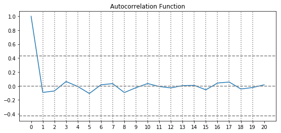

```python
from statsmodels.tsa.stattools import acf, pacf
import numpy as np
acf_msft_plot = acf(diff, nlags=20)
#Plot ACF:
plt.figure(figsize=(20, 4))

plt.subplot(121)
plt.plot(acf_msft_plot)
plt.xticks(np.arange(21))
plt.axhline(y=0,linestyle='--',color='gray')
plt.axhline(y=-1.96/np.sqrt(len(acf_msft_plot)),linestyle='--',color='gray')
plt.axhline(y=1.96/np.sqrt(len(acf_msft_plot)),linestyle='--',color='gray')
for i in range(1,20):
    plt.axvline(x=i,linestyle=':',color='gray')
plt.title('Autocorrelation Function')
```

As can be noted from the above graph, the AC plot drops immediately under UCL indicating that the time series is already stationary and no higher order differencing needs to be implemented. This is also supported by teh Dicky-Fuller test performed earlier.

## Partial Auto Correlation Function - PACF

```
Text(0.5,1,'Partial Autocorrelation Function')
```

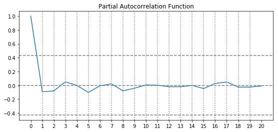

```python
pacf_msft_plot = pacf(diff, nlags=20)
#Plot ACF:
plt.figure(figsize=(20, 4))

plt.subplot(121)
plt.plot(pacf_msft_plot)
plt.xticks(np.arange(21))
plt.axhline(y=0,linestyle='--',color='gray')
plt.axhline(y=-1.96/np.sqrt(len(pacf_msft_plot)),linestyle='--',color='gray')
plt.axhline(y=1.96/np.sqrt(len(pacf_msft_plot)),linestyle='--',color='gray')
for i in range(1,20):
    plt.axvline(x=i,linestyle=':',color='gray')
plt.title('Partial Autocorrelation Function')
```

Rule 6: If the partial autocorrelation function (PACF) of the differenced series displays a sharp cutoff and/or the lag-1 autocorrelation is positive--i.e., if the series appears slightly "underdifferenced"--then consider adding one or more AR terms to the model. The lag beyond which the PACF cuts off is the indicated number of AR terms.

Rule 6 applies to our PACF curve as it sharply drops to 0 and stays within UCL and LCL. Therefore an AR term needs to be added to the model.(p = 1)

Rule 7: If the autocorrelation function (ACF) of the differenced series displays a sharp cutoff and/or the lag-1 autocorrelation is negative--i.e., if the series appears slightly "overdifferenced"--then consider adding an MA term to the model. The lag beyond which the ACF cuts off is the indicated number of MA terms.

## Fitting ARIMA model

As explained above our initial model has p=1, d=0 and q=0.

```
                              ARMA Model Results
==============================================================================
Dep. Variable:                  close   No. Observations:                 1175
Model:                     ARMA(1, 0)   Log Likelihood               -1428.662
Method:                       css-mle   S.D. of innovations              0.816
Date:                Sat, 20 Oct 2018   AIC                           2863.325
Time:                        21:08:46   BIC                           2878.532
Sample:                    01-03-2014   HQIC                          2869.059
                         - 08-31-2018
===============================================================================
                  coef    std err          z      P>|z|      [0.025      0.975]
-------------------------------------------------------------------------------
const           0.0674      0.022      3.093      0.002       0.025       0.110
ar.L1.close    -0.0924      0.029     -3.182      0.001      -0.149      -0.035
                                    Roots
=============================================================================
                 Real           Imaginary           Modulus         Frequency
-----------------------------------------------------------------------------
AR.1          -10.8216           +0.0000j           10.8216            0.5000
-----------------------------------------------------------------------------
```

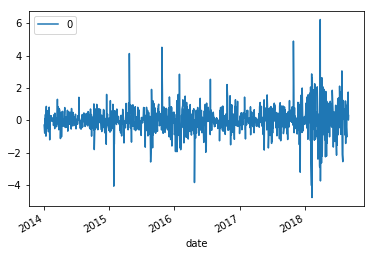

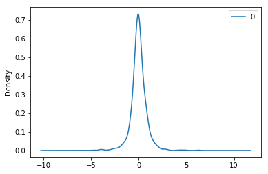

```
                 0
count  1175.000000
mean     -0.000023
std       0.816578
min      -4.771782
25%      -0.354781
50%      -0.031134
75%       0.360949
max       6.233411
```

```python
from statsmodels.tsa.arima_model import ARIMA
model = ARIMA(diff, order=(1,0,0))
model_fit = model.fit(disp=0)
print(model_fit.summary())
# plot residual errors
residuals = pd.DataFrame(model_fit.resid)
residuals.plot()
plt.show()
residuals.plot(kind='kde')
plt.show()
print(residuals.describe())
```

The residual plots seem to be normally distributed with a mean close to zero. Grid search helps to implement Brute Force technique through which optimal p, d and q values can be chosen.

## Parameter Optimization(Brute Force/ Grid Search)

```
28.099354559301922
```

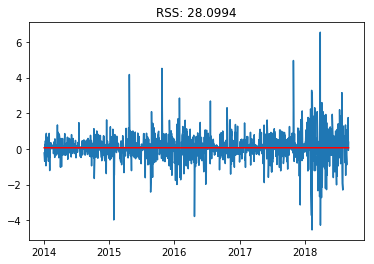

```
0 0 0
27.9594850395258
```

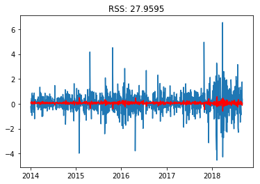

```
0 0 1
27.905792246580017
```

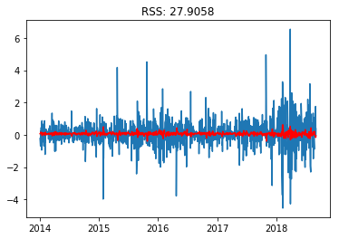

```
0 0 2
```

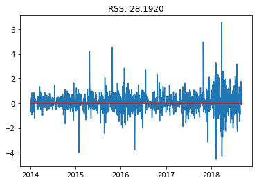

```
0 1 0
```

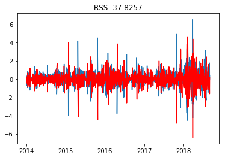

```
0 1 1
```

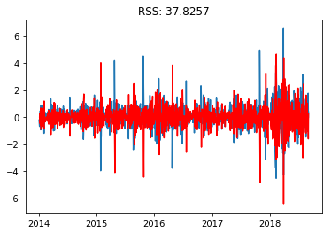

```
0 1 2
```

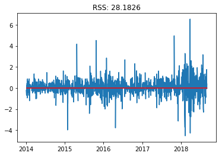

```
0 2 0
```

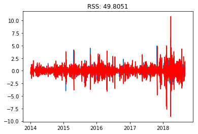

```
0 2 1
```

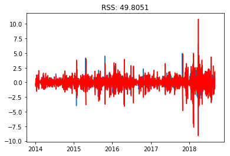

```
0 2 2
```

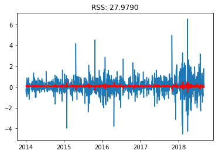

```
1 0 0
```

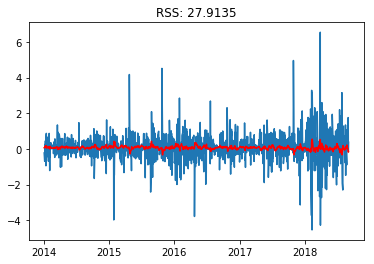

```
1 0 1
27.885866593690178
```

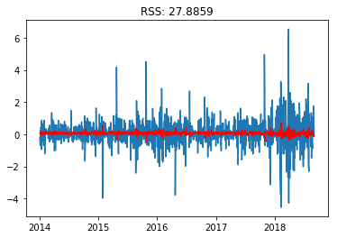

```
1 0 2
```

[15 more figures not shown]

```
3 1 2
```

```
3 2 0
```

```
3 2 1
```

```
3 2 2
```

```python
loss_best = 1E16
best_ints = [-1,-1,-1]
for p in range(4):
    for d in range(3):
        for q in range(3):
            model = ARIMA(diff, order=(p, d, q))
            try:
                results_ARIMA = model.fit(disp=-1)
            except ValueError:
                pass
            except:
                pass
            plt.plot(diff)
            plt.plot(results_ARIMA.fittedvalues, color='red')
            x=pd.DataFrame(results_ARIMA.fittedvalues)
            x=x.join(diff)
            x['out']=(x.iloc[:,0]-x.iloc[:,1])**2
            loss=np.sqrt(x['out'].sum())
            plt.title('RSS: %.4f'% loss)
            if loss < loss_best:
                print(loss)
                loss_best = loss
                best_ints=[p,d,q]
            plt.show()
            print(p,d,q)
```

```python
loss_best
```

```
27.61340978816002
```

```python
print(best_ints)
```

```
[3, 0, 2]
```

## References

[1]Prof Slater’s Jupyter Notebook sample and class material

```python
print('Thank You!')
```

```
Thank You!
```